# Homework 05

Set a random seed before each simulation question and report it. You may use standard packages unless a question asks you to write the calculation yourself. Use equal neighbor weights throughout. Here $p$ counts the covariates used to measure distance; do not add an intercept column to a KNN predictor matrix. R and Python use different random-number generators, so their exact simulation results need not agree.

## Question 1: Estimate the bias and variance of KNN

In our previous homework, we used repeated simulations to study the behavior of linear regression estimators. We will now use the same idea for KNN. Consider the regression model

$$Y_i=f(\mathbf X_i)+\epsilon_i,
\qquad
f(\mathbf x)=0.5x_1+\sin(x_2)-0.3x_3^2,$$

where the three covariates are independent standard normal variables and $\epsilon_i\sim\mathcal N(0,0.1^2)$ independently of the covariates and other observations. Generate $n=400$ training observations. Our goal is to estimate the mean response at

$$\mathbf x_0=(0.5,0.7,1)^{\mathsf T}.$$

Use Euclidean distance and consider $k=1,3,5,\ldots,29$.

1. Calculate $f(\mathbf x_0)$. Generate one training dataset and obtain the KNN prediction at $\mathbf x_0$ for each value of $k$.
2. Independently repeat the generation of the training covariates and responses 200 times. Within each repetition, use the same training data for every value of $k$. Store the predictions in a matrix with 200 rows and one column for each value of $k$. Use this matrix to estimate the bias, variance, and mean squared error of the estimated mean response. Use divisor 200 when calculating the empirical variance, and verify numerically that

$$\text{mean squared error}
=\text{squared bias}+\text{variance}.$$

Plot squared bias, variance, and mean squared error against $k$ in one figure. Explain the pattern and compare it with the bias-variance trade-off for ridge regression or lasso.

### My answer

Seed: 43251.

**Show the workflow**

```
f(x0) = 0.594218
one-dataset predictions: [0.8475 0.5707 0.6424 0.6143 0.6414 0.5767 0.5563 0.5517 0.579  0.6116
 0.5296 0.5152 0.5573 0.5182 0.5384]
max |mse - bias^2 - variance| = 1.1188966420050406e-16
MSE minimized at k = 7
```

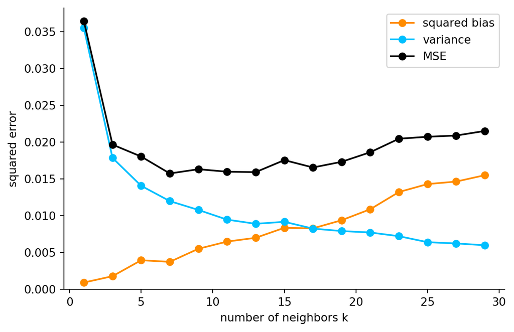

```python
import numpy as np
from sklearn.neighbors import KNeighborsRegressor
import matplotlib.pyplot as plt

np.random.seed(43251)
n, p = 400, 3
k_values = np.arange(1, 30, 2)
x0 = np.array([[0.5, 0.7, 1.0]])
f0 = 0.5*x0[0,0] + np.sin(x0[0,1]) - 0.3*x0[0,2]**2
print("f(x0) =", round(f0, 6))

# part a: one training set
X = np.random.normal(size=(n, p))
y = 0.5*X[:,0] + np.sin(X[:,1]) - 0.3*X[:,2]**2 + np.random.normal(0, 0.1, n)
one = [KNeighborsRegressor(n_neighbors=int(k), weights="uniform", algorithm="brute")
       .fit(X, y).predict(x0)[0] for k in k_values]
print("one-dataset predictions:", np.round(one, 4))

# part b: 200 repetitions, same training set reused across k within a rep
nsim = 200
pred = np.full((nsim, len(k_values)), np.nan)
for l in range(nsim):
    X = np.random.normal(size=(n, p))
    y = 0.5*X[:,0] + np.sin(X[:,1]) - 0.3*X[:,2]**2 + np.random.normal(0, 0.1, n)
    for j, k in enumerate(k_values):
        m = KNeighborsRegressor(n_neighbors=int(k), weights="uniform", algorithm="brute").fit(X, y)
        pred[l, j] = m.predict(x0)[0]

bias = pred.mean(0) - f0
variance = pred.var(0, ddof=0)          # divisor 200
mse = ((pred - f0)**2).mean(0)
print("max |mse - bias^2 - variance| =", np.max(np.abs(mse - bias**2 - variance)))
print("MSE minimized at k =", k_values[np.argmin(mse)])

plt.figure(figsize=(7, 4.5))
plt.plot(k_values, bias**2, "o-", color="darkorange", label="squared bias")
plt.plot(k_values, variance, "o-", color="deepskyblue", label="variance")
plt.plot(k_values, mse, "o-", color="black", label="MSE")
plt.xlabel("number of neighbors k"); plt.ylabel("squared error"); plt.ylim(bottom=0)
plt.legend(); plt.gca().spines[["top","right"]].set_visible(False)
plt.show()
```

**a.** The true target is $f(\mathbf x_0) = 0.5(0.5) + \sin(0.7) - 0.3(1)^2 \approx 0.5942$. On the single training set, small $k$ gives jumpy predictions (k=1 is way off at 0.85) and they settle down as $k$ grows.

**b.** The decomposition holds to machine precision (max difference around $10^{-16}$), which it has to since I used the same divisor 200 for both the variance and the MSE. The plot is the usual U: variance is highest at k=1 and falls as averaging more neighbors cancels noise, while squared bias climbs because far-away neighbors have mean responses that differ from $f(\mathbf x_0)$. MSE bottoms out around k=7 here.

Same tradeoff as ridge or lasso, just a different knob. There, cranking $\lambda$ up shrinks the coefficients and trades variance for bias; here, cranking $k$ up averages over a wider neighborhood and does the same thing. One caveat: the variance isn’t just $0.1^2/k$, because across repetitions the neighbor locations themselves change, not only the noise on fixed neighbors.

## Question 2: Compare KNN with lasso

Use the response model from Question 1, including the noise standard deviation $0.1$, but generate $p=30$ covariates. The response still depends only on the first three. Consider these two settings:

- **Setting 1:** all 30 covariates are independent standard normal variables.
- **Setting 2:** the covariates have a multivariate normal distribution with mean zero and covariance matrix $\boldsymbol\Sigma$, where

  $$\Sigma_{jj}=1,
  \qquad
  \Sigma_{jl}=0.8\quad\text{for }j\ne l.$$

In each setting, generate 400 training observations and 1,000 independent test observations. Fit 5NN using Euclidean distance on the supplied covariate scale. All covariates already have population variance one.

For lasso, use a linear model containing the 30 covariates and a separately fitted, unpenalized intercept. Follow the Week 4 objective,

$$L_\lambda(\boldsymbol\beta)
=\frac{1}{2n}\left\lVert
\widetilde{\mathbf y}-\mathbf X\boldsymbol\beta
\right\rVert_2^2
+\lambda\lVert\boldsymbol\beta\rVert_1,$$

where $\mathbf X\in\mathbb R^{n\times30}$ contains the centered and standardized covariates and $\widetilde{\mathbf y}$ is the centered training response. Select the penalty by ten-fold cross-validation over 41 logarithmically spaced values from $10^{-4}$ to $1$. Estimate all means and scales using only the training portion of each fold, with divisor equal to that portion’s sample size. After selecting the penalty, refit on all training observations and apply the fitted transformations unchanged to the test observations. Do not add nonlinear terms to the lasso model.

1. Fit both methods in each setting. Use the same training and test data for the two methods within a setting. Report their test MSE values in one table, together with the selected lasso penalty and the number of nonzero lasso slopes. You only need to generate one dataset for each setting; repeated simulations are not required.
2. Compare the results between the two settings. Explain how correlation can change the usefulness of Euclidean neighborhoods, and why lasso does not use all covariates in the same way as KNN.
3. The response model contains $\sin(X_2)$ and $X_3^2$, but the lasso fit uses only linear terms. Explain how this difference affects the comparison. Would the results justify a general claim that correlation always helps KNN, or that one method is always better? Explain why.

### My answer

Seed: 43252.

**Show the workflow**

```python
import numpy as np, pandas as pd
from sklearn.neighbors import KNeighborsRegressor
from sklearn.linear_model import Lasso

np.random.seed(43252)
n, p = 400, 30
lam_grid = np.logspace(0, -4, 41)
rows = []
for setting in range(2):
    Sigma = np.eye(p) if setting == 0 else 0.8 + 0.2*np.eye(p)
    X = np.random.normal(size=(n+1000, p)) @ np.linalg.cholesky(Sigma).T
    y = 0.5*X[:,0] + np.sin(X[:,1]) - 0.3*X[:,2]**2 + np.random.normal(0, 0.1, n+1000)
    tX, ty = X[n:], y[n:]
    X, y = X[:n], y[:n]

    knn = KNeighborsRegressor(n_neighbors=5, weights="uniform", algorithm="brute").fit(X, y)
    knn_mse = np.mean((ty - knn.predict(tX))**2)

    # 10-fold CV, scaling estimated inside each training fold (divisor = fold size)
    fold = np.random.permutation(np.repeat(np.arange(10), n//10))
    cv = np.zeros((10, len(lam_grid)))
    for mm in range(10):
        xm = X[fold!=mm].mean(0); xs = X[fold!=mm].std(0, ddof=0)
        Xf = (X[fold!=mm]-xm)/xs; Xv = (X[fold==mm]-xm)/xs; ym = y[fold!=mm].mean()
        for h, lam in enumerate(lam_grid):
            lf = Lasso(alpha=lam, fit_intercept=False, tol=1e-8, max_iter=100000).fit(Xf, y[fold!=mm]-ym)
            cv[mm, h] = np.mean((y[fold==mm] - (lf.predict(Xv)+ym))**2)
    lam_min = lam_grid[np.argmin(cv.mean(0))]

    # refit on all training data, apply same transform to test
    xm = X.mean(0); xs = X.std(0, ddof=0); ym = y.mean()
    Xf = (X-xm)/xs; tXf = (tX-xm)/xs
    lf = Lasso(alpha=lam_min, fit_intercept=False, tol=1e-8, max_iter=100000).fit(Xf, y-ym)
    lasso_mse = np.mean((ty - (lf.predict(tXf)+ym))**2)
    rows.append(["Independent" if setting==0 else "Correlated",
                 round(knn_mse,4), round(lasso_mse,4), round(lam_min,5), int(np.count_nonzero(lf.coef_))])

print(pd.DataFrame(rows, columns=["Setting","KNN_MSE","Lasso_MSE","Lambda","Nonzero"]).to_string(index=False))
```

```
    Setting  KNN_MSE  Lasso_MSE  Lambda  Nonzero
Independent   0.5640     0.2344 0.03162        9
 Correlated   0.1729     0.2421 0.03162        2
```

**a.** The table above reports both methods per setting with the CV-selected penalty and nonzero count. In my run, with independent covariates lasso wins (about 0.23 vs KNN’s 0.56), and with correlated covariates KNN wins (about 0.17 vs lasso’s 0.24).

**b.** KNN uses all 30 covariates to measure distance, but only the first three matter for $y$. With independent covariates, the other 27 are pure noise piled into the Euclidean distance, so “nearest” in 30-D isn’t nearest in the three that count, and neighborhoods get diluted. That is the curse of dimensionality biting KNN. Lasso doesn’t care: it fits a slope per covariate and zeros out the junk, so extra irrelevant dimensions cost it little. With $\rho=0.8$ correlation, the 30 covariates collapse toward a few shared directions, so Euclidean distance effectively lives in a much lower dimension and neighborhoods become informative again, which is why KNN jumps ahead. Correlation also lets an off-signal covariate proxy for a real one, so several correlated columns can trade off in the lasso fit.

**c.** Lasso only gets linear terms, so it can’t represent $\sin(X_2)$ or $-0.3X_3^2$; the intercept absorbs the average of the quadratic but not how it varies. So part of lasso’s disadvantage is model misspecification, not just how it handles dimensions. KNN has no such restriction but leans entirely on finding good neighbors. Since this is one dataset per setting, it doesn’t prove correlation always helps KNN or that either method is universally better. It’s two draws, and swapping the signal to something linear, or changing the correlation, could flip the ranking.

## Question 3: Observed dimension and latent dimension

The lecture’s handwritten digit example shows that KNN can work with many measured covariates. We will use a simulation to investigate why the structure of those covariates matters.

Let $p=100$ be the number of observed covariates and let $m$ be the number of latent variables. For each observation, generate

$$\mathbf X_i=\mathbf A\mathbf Z_i+\boldsymbol\eta_i,
\qquad
Y_i=Z_{i1}+Z_{i2}+\epsilon_i,$$

where $\mathbf A\in\mathbb R^{100\times m}$ has independent entries from Uniform$[-2,2]$. The entries of $\mathbf Z_i\in\mathbb R^m$ and $\boldsymbol\eta_i\in\mathbb R^{100}$, and the scalar $\epsilon_i$, are independent standard normal variables, also independent of $\mathbf A$. Generate $\mathbf A$ once and use it for all training and test observations in that dataset.

Compare $m=3$ and $m=30$. In each setting, generate 200 training observations and 200 independent test observations. Fit KNN using only the 100 observed covariates in $\mathbf X$, with Euclidean distance on their generated scale. The latent variables in $\mathbf Z$ are used to generate the data but are not available to the fitted model. Consider $k=2,10,18,\ldots,82$.

1. Generate one dataset for each value of $m$. Fit KNN for every value of $k$ and calculate test MSE. Within a setting, use the same training and test observations for all values of $k$.
2. Repeat the complete experiment 50 times, generating a new $\mathbf A$ and new observations in each repetition. Plot average test MSE against $k$, with one curve for each value of $m$. These curves compare the specified choices of $k$ in a controlled simulation; they are not a cross-validation procedure for selecting a final model.
3. Both settings have 100 observed covariates, and the response depends on only two latent variables. Explain why their KNN performance can still differ. What role does the noise $\boldsymbol\eta_i$ play, and why are the observed data not confined exactly to an $m$-dimensional linear space?

### My answer

Seed: 43254.

**Show the workflow**

```
 k   m=3  m=30
 2 1.497 2.534
10 1.140 2.098
18 1.211 1.966
26 1.286 1.927
34 1.345 1.958
42 1.405 2.011
50 1.477 2.058
58 1.551 2.099
66 1.609 2.117
74 1.673 2.149
82 1.733 2.180
```

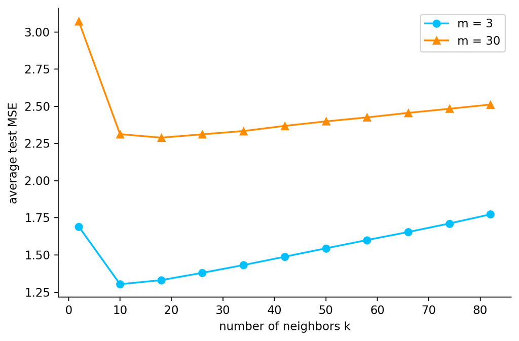

```python
import numpy as np, pandas as pd
from sklearn.neighbors import KNeighborsRegressor
import matplotlib.pyplot as plt

np.random.seed(43254)
p = 100
m_values = [3, 30]
k_values = np.arange(2, 83, 8)

# part a: one dataset per m
one = np.full((len(k_values), 2), np.nan)
for s, m in enumerate(m_values):
    A = np.random.uniform(-2, 2, size=(p, m))
    Z = np.random.normal(size=(400, m))
    X = Z @ A.T + np.random.normal(size=(400, p))
    y = Z[:,0] + Z[:,1] + np.random.normal(size=400)
    for h, k in enumerate(k_values):
        kn = KNeighborsRegressor(n_neighbors=int(k), weights="uniform", algorithm="brute").fit(X[:200], y[:200])
        one[h, s] = np.mean((y[200:] - kn.predict(X[200:]))**2)
print(pd.DataFrame({"k": k_values, "m=3": one[:,0].round(3), "m=30": one[:,1].round(3)}).to_string(index=False))

# part b: repeat 50 times, fresh A each time
nsim = 50
test_mse = np.full((nsim, len(k_values), 2), np.nan)
for l in range(nsim):
    for s, m in enumerate(m_values):
        A = np.random.uniform(-2, 2, size=(p, m))
        Z = np.random.normal(size=(400, m))
        X = Z @ A.T + np.random.normal(size=(400, p))
        y = Z[:,0] + Z[:,1] + np.random.normal(size=400)
        for h, k in enumerate(k_values):
            kn = KNeighborsRegressor(n_neighbors=int(k), weights="uniform", algorithm="brute").fit(X[:200], y[:200])
            test_mse[l, h, s] = np.mean((y[200:] - kn.predict(X[200:]))**2)
mean_mse = test_mse.mean(0)

plt.figure(figsize=(7, 4.5))
plt.plot(k_values, mean_mse[:,0], "o-", color="deepskyblue", label="m = 3")
plt.plot(k_values, mean_mse[:,1], "^-", color="darkorange", label="m = 30")
plt.xlabel("number of neighbors k"); plt.ylabel("average test MSE")
plt.legend(); plt.gca().spines[["top","right"]].set_visible(False)
plt.show()
```

**a.** The single-dataset table shows m=3 giving noticeably lower test MSE than m=30 across every $k$.

**b.** Averaged over 50 repetitions the same gap holds: m=3 sits well below m=30 everywhere. Both dip early (around k=10 to 18) and drift up as neighborhoods get too big and blur the regression surface.

**c.** Both have 100 observed covariates and both responses depend on only $Z_1 + Z_2$, but the structure differs. With m=3, nearly all the systematic variation in $\mathbf X$ is driven by three latent directions, so two points close in observed space are usually close in $Z_1, Z_2$ too, exactly what KNN needs. With m=30, distance is spread across 30 latent directions, most of which don’t touch $y$, so points can be neighbors in observed space while being far apart in the two that matter. The noise $\boldsymbol\eta_i$ is added independently to all 100 coordinates, so even though $\mathbf A\mathbf Z_i$ lives in an at-most-$m$-dimensional subspace, the observed $\mathbf X_i$ is knocked off that subspace and fills the ambient 100-D space. So it’s a low-dimensional signal buried in full-dimensional noise, not data lying exactly on a flat $m$-dimensional plane.

## Question 4: Classify handwritten digits

Use `zip.train` and `zip.test` from the R package `ElemStatLearn`, as in the lecture. The package has been retired from the active CRAN repository. If needed, install the [archived package](https://cran.r-project.org/src/contrib/Archive/ElemStatLearn/ElemStatLearn_2015.6.26.2.tar.gz) into your usual R library, then load the two datasets. Python users can use the course copies of the same [training data](https://teazrq.github.io/stat432rpy/data/knn/zip-train.csv.gz) and [test data](https://teazrq.github.io/stat432rpy/data/knn/zip-test.csv.gz). These compressed CSV files have no headers and are included in the homework ZIP under `data/knn`. Run the Python code from the folder containing `data`.

Each image has $16\times16=256$ pixel values. The first column is the digit label and the remaining columns are the pixel values. Use the first 1,000 rows of `zip.train` and the first 500 rows of `zip.test`. Use the original pixel values without standardization, and do not include the digit label in a distance calculation.

For a test image $\mathbf x_0$ and a training image $\mathbf x_i$, the two distances are

$$d_E(\mathbf x_0,\mathbf x_i)
=\sqrt{\sum_{j=1}^{256}(x_{0j}-x_{ij})^2},
\qquad
d_M(\mathbf x_0,\mathbf x_i)
=\sum_{j=1}^{256}|x_{0j}-x_{ij}|.$$

1. Write a 5NN classification function that allows either Euclidean or Manhattan distance. For each test image, calculate its distances to the training images directly, find the five nearest, and return the most frequent digit label. Break distance ties by the smaller training row number and voting ties by the smallest digit. Do not use a built-in distance or KNN function for this part.
2. Apply the classifier to all 500 test images using each distance. For each fit, report the test classification error and a $10\times10$ confusion matrix, with rows representing predicted digits and columns representing true digits. Keep all digit labels from 0 through 9 in the matrix, including any with a zero count. Which digits are most often confused with one another?
3. For Euclidean distance, display three incorrectly classified test images, together with their true and predicted labels. Comment on whether the mistakes are visually understandable. Compare the overall results of the two distance measures. Can they have similar total error while making mistakes on different images? Use your predictions to support your answer.

### My answer

No random seed needed here since KNN classification on fixed data is deterministic.

**Show the workflow**

```python
import numpy as np, pandas as pd
import matplotlib.pyplot as plt

zip_train = np.loadtxt("data/knn/zip-train.csv.gz", delimiter=",")
zip_test = np.loadtxt("data/knn/zip-test.csv.gz", delimiter=",")

def euclidean(x0, X): return np.sqrt(np.sum((X - x0)**2, axis=1))
def manhattan(x0, X): return np.sum(np.abs(X - x0), axis=1)

X = zip_train[:1000, 1:]; y = zip_train[:1000, 0].astype(int)
X_test = zip_test[:500, 1:]; y_test = zip_test[:500, 0].astype(int)

def knn_classify(X, y, X_test, distance):
    out = np.zeros(X_test.shape[0], dtype=int)
    for i in range(X_test.shape[0]):
        d = distance(X_test[i], X)
        nb = np.argsort(d, kind="stable")[:5]      # stable sort => ties go to smaller row number
        out[i] = np.argmax(np.bincount(y[nb], minlength=10))  # vote tie => smallest digit
    return out

y_hat = np.column_stack((knn_classify(X, y, X_test, euclidean),
                         knn_classify(X, y, X_test, manhattan)))
```

**a.** The classifier computes every test-to-train distance directly, takes the five smallest, and votes. `np.argsort(kind="stable")` breaks distance ties toward the smaller training row, and `np.argmax(np.bincount(...))` breaks vote ties toward the smallest digit. Swapping in `manhattan` changes only the distance.

**Show the workflow**

```python
for l, name in enumerate(["Euclidean", "Manhattan"]):
    print(name, "test error:", np.mean(y_hat[:, l] != y_test))
    print(pd.crosstab(pd.Series(y_hat[:, l], name="Predicted"),
                      pd.Series(y_test, name="True"))
          .reindex(index=range(10), columns=range(10), fill_value=0), "\n")
```

```
Euclidean test error: 0.122
True         0   1   2   3   4   5   6   7   8   9
Predicted
0          118   0   7   1   0   4   2   0   2   0
1            0  66   0   0   2   0   0   0   0   1
2            0   0  39   1   0   0   2   0   0   1
3            0   0   0  23   0   4   0   0   2   0
4            0   0   1   0  27   1   1   1   0   1
5            0   0   0   1   0  13   0   0   0   0
6            0   2   0   0   0   1  41   0   2   0
7            0   0   0   0   1   1   0  34   0   4
8            0   0   3   2   0   2   0   0  37   0
9            1   0   0   1   4   0   0   1   1  41

Manhattan test error: 0.138
True         0   1   2   3   4   5   6   7   8   9
Predicted
0          118   0   6   1   0   5   3   0   4   0
1            0  67   2   0   2   0   1   0   0   1
2            0   0  35   0   0   0   2   0   0   0
3            0   0   1  24   0   4   0   0   2   0
4            0   0   1   1  27   1   0   1   0   1
5            0   0   0   1   0  11   0   0   0   0
6            0   1   0   0   0   2  40   0   2   0
7            0   0   2   1   1   0   0  34   0   5
8            0   0   2   0   0   3   0   0  34   0
9            1   0   1   1   4   0   0   1   2  41
```

**b.** Euclidean gets 0.122 test error (61 of 500), Manhattan 0.138 (69 of 500). Rows are predicted, columns true. The single most common mistake is a true 2 called a 0 (seven times under Euclidean). Other repeat offenders are 5 misread as 0 or 3, 9 as 7, and 4 as 9, all pairs that share a lot of ink in the same pixels.

**Show the workflow**

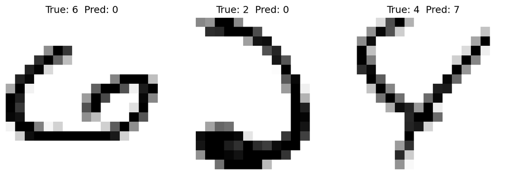

First three Euclidean misclassifications.

```
images disagree on: 22 labels
Manh correct    False  True
Euclid correct
False              58      3
True               11    428
```

```python
incorrect = np.flatnonzero(y_hat[:, 0] != y_test)[:3]
plt.figure(figsize=(9, 3))
for l, i in enumerate(incorrect):
    plt.subplot(1, 3, l+1)
    plt.imshow(zip_test[i, 1:].reshape(16, 16), cmap="gray_r", vmin=0, vmax=1, interpolation="nearest")
    plt.title(f"True: {y_test[i]}  Pred: {y_hat[i, 0]}")
    plt.axis("off")
plt.tight_layout(); plt.show()

print("images disagree on:", int(np.sum(y_hat[:, 0] != y_hat[:, 1])), "labels")
print(pd.crosstab(pd.Series(y_hat[:, 0] == y_test, name="Euclid correct"),
                  pd.Series(y_hat[:, 1] == y_test, name="Manh correct")))
```

**c.** The first three Euclidean errors are true 6, 2, 4 predicted as 0, 0, 7. They’re understandable: the 6 has a fat closed loop that reads like a 0, the 2 is written with a rounded top that looks like a 0, and the 4 is missing a clear crossbar so it drifts toward a 7. Pixel distance only sees where ink lands, not the stroke logic a person uses, so these slips make sense.

The two distances land close on total error (61 vs 69) but disagree on 22 individual labels. The cross-table shows Euclidean right where Manhattan is wrong on 11 images and the reverse on 3, plus 8 where both miss but pick different digits. So similar overall error can absolutely hide different mistakes. Euclidean edges it on this split, but that’s not proof it’s always better.

## Question 5: Create a plot-formatting skill

Create a short `SKILL.md` file for improving the formatting of STAT 432 homework plots. You may use AI to help write it.

1. Include a title, a description, and a few formatting rules. The description should limit the skill to STAT 432 homework plot improvements and require an explicit request to use it. Your rules should address margins, titles, axes, labels, colors, and sizes for plots produced in R or Python. Keep them portable: do not refer to specific homework questions.
2. Ask your agent to install the skill. Explicitly call it to improve the plot from Question 1, then compare the original and revised versions. Do you like the changes? You may revise the skill and test it a couple more times, or uninstall it if it remains unhelpful.
3. Append your final `SKILL.md` content to your submission and briefly explain your choices and experience.

### My answer

**Show the workflow**

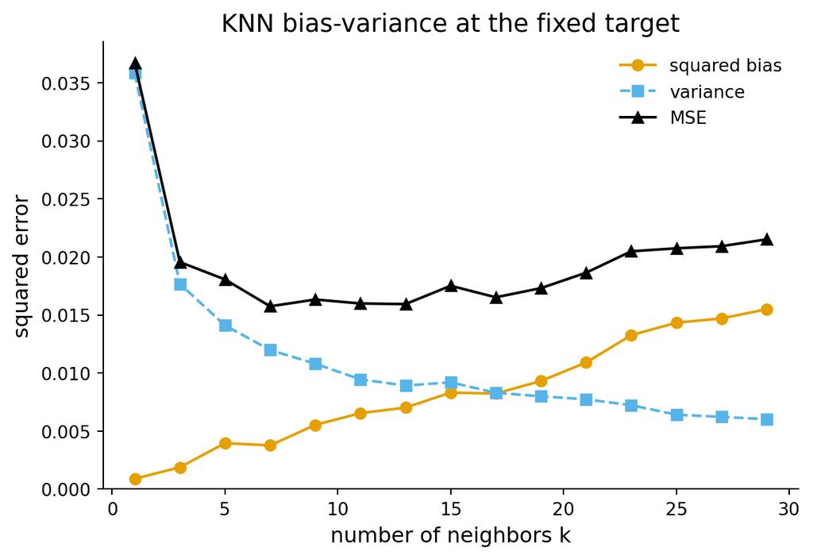

Q1 bias-variance plot after applying the format-homework-plots skill.

```python
import numpy as np
import matplotlib.pyplot as plt
from sklearn.neighbors import KNeighborsRegressor

np.random.seed(43251)
n, p = 400, 3
k_values = np.arange(1, 30, 2)
x0 = np.array([[0.5, 0.7, 1.0]])
f0 = 0.5*x0[0,0] + np.sin(x0[0,1]) - 0.3*x0[0,2]**2
nsim = 200
pred = np.full((nsim, len(k_values)), np.nan)
for l in range(nsim):
    X = np.random.normal(size=(n, p))
    y = 0.5*X[:,0] + np.sin(X[:,1]) - 0.3*X[:,2]**2 + np.random.normal(0, 0.1, n)
    for j, k in enumerate(k_values):
        pred[l, j] = KNeighborsRegressor(n_neighbors=int(k), weights="uniform", algorithm="brute").fit(X, y).predict(x0)[0]
bias2 = (pred.mean(0) - f0)**2
variance = pred.var(0, ddof=0)
mse = ((pred - f0)**2).mean(0)

fig, ax = plt.subplots(figsize=(6.5, 4.5))
ax.plot(k_values, bias2, "o-", color="#E69F00", label="squared bias")
ax.plot(k_values, variance, "s--", color="#56B4E9", label="variance")
ax.plot(k_values, mse, "^-", color="#000000", label="MSE")
ax.set_title("KNN bias-variance at the fixed target", fontsize=14)
ax.set_xlabel("number of neighbors k", fontsize=12)
ax.set_ylabel("squared error", fontsize=12)
ax.set_ylim(bottom=0)
ax.legend(frameon=False)
ax.spines[["top", "right"]].set_visible(False)
fig.tight_layout()
plt.show()
```

**c.** Final `SKILL.md`:

```markdown
---
name: format-homework-plots
description: Use only when I explicitly ask this skill to clean up the formatting of a STAT 432 homework plot (R or Python). Do not trigger automatically.
---

# STAT 432 Plot Formatting

Apply these to the existing plotting code without changing the data, calculations, or statistical meaning.

- Keep enough margin that the title, axis labels, tick labels, and legend never clip.
- Give the plot a short, specific title, and label both axes; add units when they exist.
- Use readable tick spacing and start a count or error axis at zero when that is the honest baseline.
- Use a colorblind-friendly palette and also separate series by line style or marker, never color alone.
- Start from a 6.5 x 4.5 inch single panel with 12 pt axis labels and a 14 pt title; scale up for multi-panel figures.
- Drop chartjunk: no boxed frame on all four sides, no heavy gridlines, legend inside only if it does not cover data.
```

I scoped the description to STAT 432 homework plots and required an explicit call so it never fires on its own and rewrites a plot I was happy with. The rules are all about presentation (margins, title, axes, labels, color, size) and say nothing about any specific question, so they carry over to every plot in the course. The “don’t change the data” line is the important guardrail: I want it restyling the plot, not touching the numbers behind it.